# Resolução da Lista 2

### Questão 8

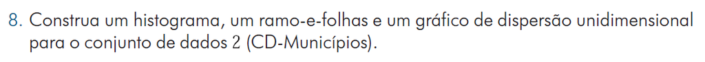

##### ºHistograma

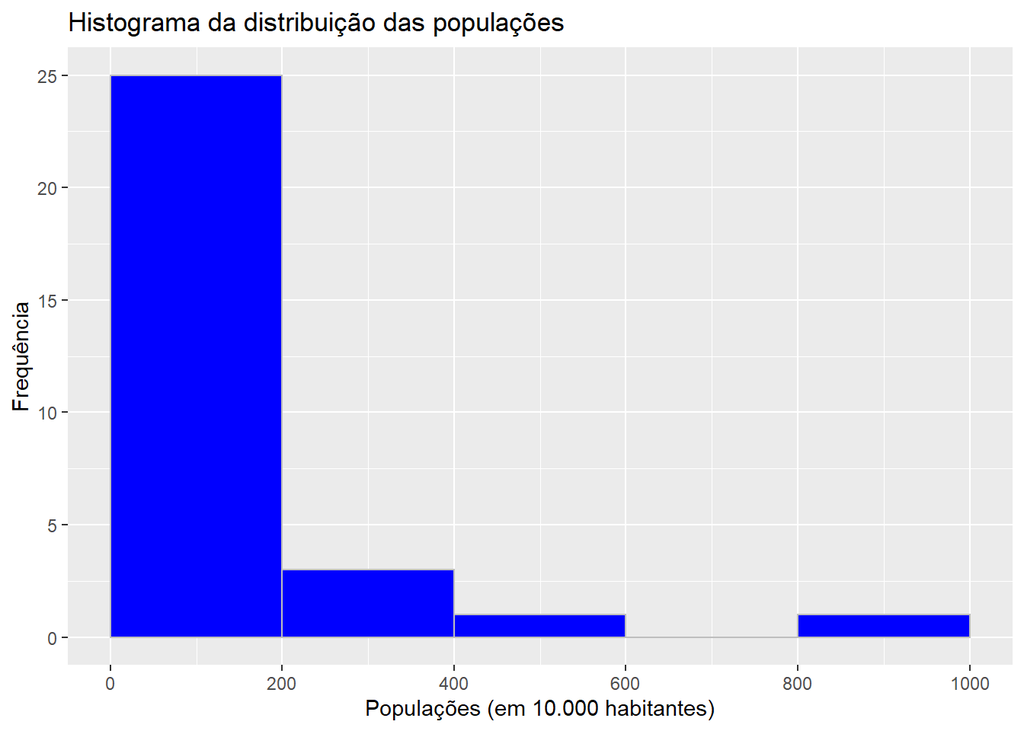

```r
ggplot(data = cd_municipios,
       aes(x = populacao)) +
  geom_histogram(breaks=seq(0,1000, by=200),
                 col="gray",
                 fill="blue") +
  labs(title="Histograma da distribuição das populações",
       x="Populações (em 10.000 habitantes)",
       y="Frequência") +
  scale_x_continuous(breaks=seq(0,1000,200))
```

##### ºRamo-e-folhas

```r
stem(cd_municipios$populacao, scale =16)
```

```
##
##   The decimal point is 1 digit(s) to the right of the |
##
##    4 | 6
##    5 | 0046
##    6 | 234778
##    7 | 35
##    8 | 045
##    9 | 2
##   10 | 22
##   11 | 69
##   12 |
##   13 | 06
##   14 |
##   15 | 2
```

[output cut: 83 more lines]

##### ºGráfico de dispersão unidimensional

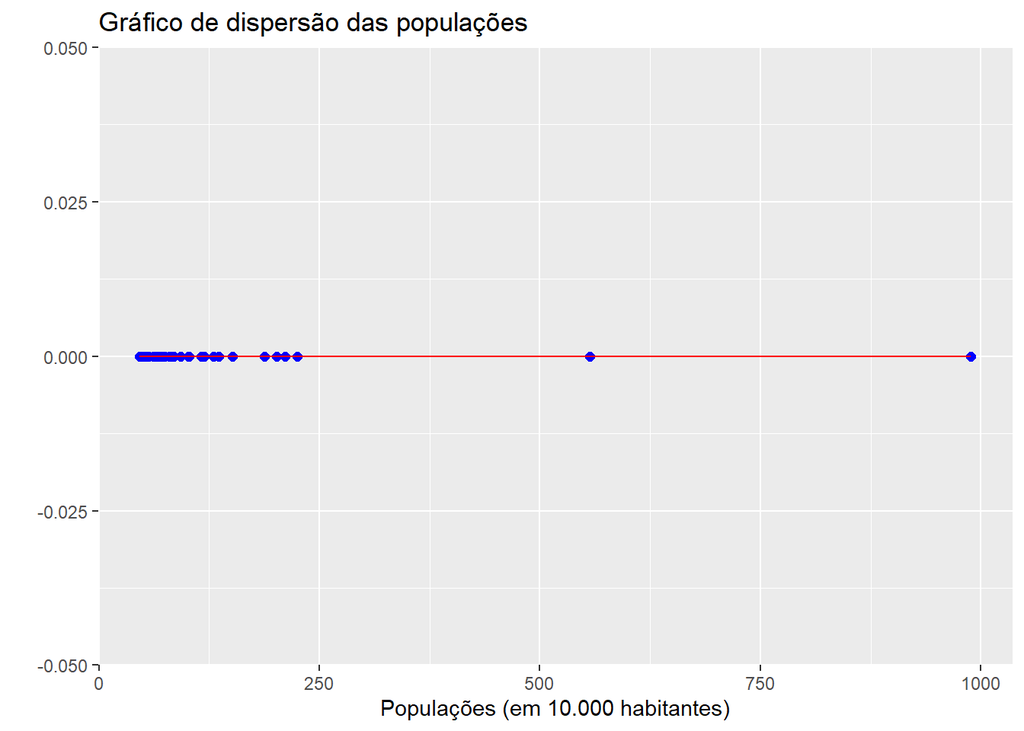

```r
ggplot(data = cd_municipios, aes(populacao, 0)) +
  geom_point(col='blue', size =2) +
  labs(title="Gráfico de dispersão das populações",
       x="Populações (em 10.000 habitantes)",
       y=" ") +
  geom_line(col = "red")
```

### Questão 20

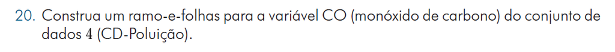

##### ºRamo-e-folhas

```r
stem(cd_poluicao$co)
```

```
##
##   The decimal point is at the |
##
##    4 | 77
##    5 | 12
##    5 | 55677789
##    6 | 1111122222222233333444444
##    6 | 5666677777899999999
##    7 | 00122233444
##    7 | 5566777778888899999999
##    8 | 012334
##    8 | 55678999
##    9 | 0114
##    9 | 557
##   10 | 1333
##   10 | 8
##   11 | 4
##   11 | 69
##   12 | 0
##   12 | 5
```

# Capítulo 3

### Questão 18

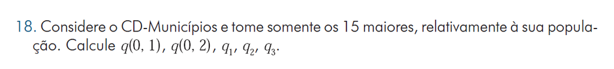

```r
Pop <- cd_municipios$populacao

#Ordenando o vetor em  ordem decrescente:
Pop <- sort(Pop,decreasing = TRUE)

#Ordenando o novo vetor que contém as 15 maiores.
Pop <- sort(Pop[1:15])

# Novo conjunto de dados
Pop
```

```
##  [1]  84.7  92.4 101.8 102.3 116.0 119.4 129.8 135.8 151.6 187.7 201.5 210.9
## [13] 224.6 556.9 988.8
```

```r
# Quantis q(0,1), q(0,2), q1=q(0,25), q2=q(0,5)=Mediana e q3=q(0,75)
quantile(Pop, probs = c(0.1, 0.2, 0.25, 0.5, 0.75))
```

```
##    10%    20%    25%    50%    75%
##  96.16 102.20 109.15 135.80 206.20
```

### Questão 42

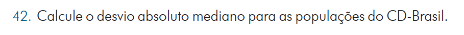

##### Para essa e outras questões, vamos precisar do conceito de desvio absoluto mediano (dam):

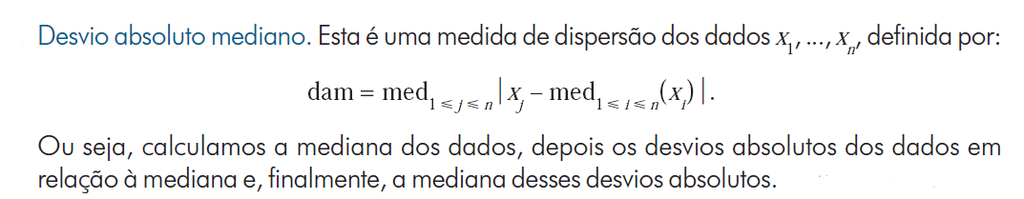

##### ºPopulação Urbana

```r
Pop_Urb <- cd_brasil$pop_urbana
Pop_Urb <- Pop_Urb[!is.na(Pop_Urb)]

Desv_Abs_Median <- median(abs(Pop_Urb-median(Pop_Urb)))
Desv_Abs_Median
```

```
## [1] 1413142
```

##### ºPopulação Rural

```r
Pop_Rur <- cd_brasil$pop_rural
Pop_Rur <- sort(Pop_Rur[!is.na(Pop_Rur)])

Desv_Abs_Median <- median(abs(Pop_Rur-median(Pop_Rur)))
Desv_Abs_Median
```

```
## [1] 546852
```

### Questão 43

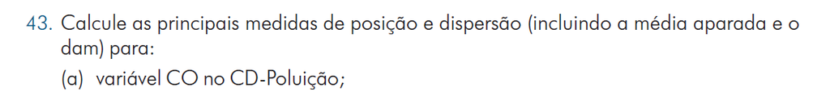

##### ºMedidas de posição

```r
Mono_Carb <- cd_poluicao$co
#Média
mean(Mono_Carb)
```

```
## [1] 7.464167
```

```r
#Mediana
median(Mono_Carb)
```

```
## [1] 7.2
```

```r
#Moda
#OBS.: O próprio conjunto de dados fornecido ("dados.RData") nos dá uma função "moda2"
#que calcula a moda de um conjunto, mas não vamos considerar essa função
#para a resolução da questão. Ex.:
moda2(Mono_Carb)
```

```
## [1] "6.2"
```

```r
#Para calcular a moda, pelo fato de o R não possuir uma função built-in para tal, assim
#como tem para calcular a média ou a mediana, vamos utilizar outro método.
#Aqui, pegamos as repetições das observações com a função "table"
table(Mono_Carb)
```

```
## Mono_Carb
##  4.7  5.1  5.2  5.5  5.6  5.7  5.8  5.9  6.1  6.2  6.3  6.4  6.5  6.6  6.7  6.8
##    2    1    1    2    1    3    1    1    5    9    5    6    1    4    5    1
##  6.9    7  7.1  7.2  7.3  7.4  7.5  7.6  7.7  7.8  7.9    8  8.1  8.2  8.3  8.4
##    8    2    1    3    2    3    2    2    5    5    8    1    1    1    2    1
##  8.5  8.6  8.7  8.8  8.9    9  9.1  9.4  9.5  9.7 10.1 10.3 10.8 11.4 11.6 11.9
##    2    1    1    1    3    1    2    1    2    1    1    3    1    1    1    1
##   12 12.5
##    1    1
```

```r
#Aqui, já conseguimos observar que o número 6.2 foi o que se repetiu mais vezes (9),
#mas queremos que o R busque isso para a gente.

#Então, o que queremos é o nome da "coluna" que corresponde ao valor máximo
#de repetições [table(Mono_Carb)]
names(table(Mono_Carb)[table(Mono_Carb)==max(table(Mono_Carb))])
```

```
## [1] "6.2"
```

##### ºMedidas de dispersão

```r
#Desvio Médio
#Igual ao somatório do valor absoluto das distâncias de cada observação à média,
#dividido pelo total de observações.
print(sum(abs(Mono_Carb-mean(Mono_Carb)))/length(Mono_Carb))
```

```
## [1] 1.181653
```

```r
#variância
#Aqui foi preciso converter a Variância Amostral para Variância Populacional
#multiplicando por (n-1) e dividindo por (n).
var(Mono_Carb)*(length(Mono_Carb)-1)/length(Mono_Carb)
```

```
## [1] 2.363799
```

```r
#Desvio Padrão
#Igual à raiz quadrada da Variância.
Var <- var(Mono_Carb)*(length(Mono_Carb)-1)/length(Mono_Carb)
print(Var^(1/2))
```

```
## [1] 1.537465
```

```r
#Média Aparada [x(0,10)]
#Vamos ordenar as observações em ordem crescente:
Mono_Carb_O <- sort(Mono_Carb)
#Agora, vamos calcular a quantidade de observações (100α%, com α=0,10) a qual vamos precisar
#remover essa quantidade das menores observações e essa quantidade das maiores:
Qtd_Observ <- (length(Mono_Carb_O)*0.10)
Qtd_Observ
```

```
## [1] 12
```

```r
#Agora, removemos 12 das menores e das maiores observções, e calculamos a média
#(assim, teremos a média aparada):
Mono_Carb_R <- Mono_Carb_O[(Qtd_Observ+1):(length(Mono_Carb_O)-Qtd_Observ)]
mean(Mono_Carb_R)
```

```
## [1] 7.29375
```

##### (b)

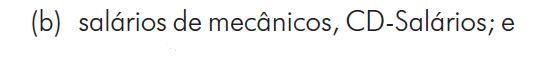

##### ºMedidas de posição

```r
Salarios <- cd_salarios$Mecânico
#Média
mean(Salarios)
```

```
## [1] 18.58907
```

```r
#Mediana
median(Salarios)
```

```
## [1] 16.435
```

```r
#Moda
#Usaremos o mesmo método do item (a):
names(table(Salarios)[table(Salarios)==max(table(Salarios))])
```

```
## [1] "20.068" "25.95"
```

##### ºMedidas de dispersão

```r
#Desvio Médio
#Igual ao somatório do valor absoluto das distâncias de cada observação à média,
#dividido pelo total de observações.
print(sum(abs(Salarios-mean(Salarios)))/length(Salarios))
```

```
## [1] 9.768942
```

```r
#variância
#Aqui foi preciso converter a Variância Amostral para Variância Populacional #multiplicando por (n-1) e dividindo por (n).
var(Salarios)*(length(Salarios)-1)/length(Salarios)
```

```
## [1] 129.6838
```

```r
#Desvio Padrão
#Igual à raiz quadrada da Variância.
Var <- var(Salarios)*(length(Salarios)-1)/length(Salarios)
print(Var^(1/2))
```

```
## [1] 11.38788
```

```r
#Média Aparada [x(0,10)]
#Vamos ordenar as observações em ordem crescente:
Salarios_O <- sort(Salarios)

#Agora, vamos calcular a quantidade de observações (100α($\alpha$)%, com α($\alpha$)=0,10) a qual
#vamos precisar remover essa quantidade das menores observações e essa quantidade das maiores:
Qtd_Observ <- (length(Salarios_O)*0.10)
Qtd_Observ
```

```
## [1] 3
```

```r
#Agora, removemos 3 das menores e das maiores observções, e calculamos a média
#(assim, teremos a média aparada):
Salarios_R <- Salarios_O[(Qtd_Observ+1):(length(Salarios_O)-Qtd_Observ)]
mean(Salarios_R)
```

```
## [1] 17.9245
```

##### (c)

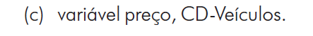

##### ºMedidas de posição

```r
Preco <- cd_veiculos$preco
#Média
mean(Preco)
```

```
## [1] 13956.1
```

```r
#Mediana
median(Preco)
```

```
## [1] 11824
```

```r
#Moda
#Utilizaremos o mesmo metódo descrito no item (a):
names(table(Preco)[table(Preco)==max(table(Preco))])
```

```
##  [1] "5257"  "5680"  "6176"  "6260"  "6316"  "6340"  "6700"  "7742"  "7780"
## [10] "9300"  "9440"  "10532" "10767" "11386" "11630" "12018" "12890" "12923"
## [19] "13140" "13700" "13840" "14460" "15520" "16346" "21500" "22200" "24632"
## [28] "31640" "33718" "38850"
```

```r
#percebemos que a Moda é igual ao número total de observações:
length(Preco)==length(names(table(Preco)[table(Preco)==max(table(Preco))]))
```

```
## [1] TRUE
```

```r
#Logo, concluímos que a distribuição não tem um valor que se repete, ou seja, não possui uma moda.
```

##### ºMedidas de dispersão

```r
#Desvio Médio
#Igual ao somatório do valor absoluto das distâncias de cada observação à média,
#dividido pelo total de observações.
print(sum(abs(Preco-mean(Preco)))/length(Preco))
```

```
## [1] 6217.407
```

```r
#variância
#Aqui foi preciso converter a Variância Amostral para Variância Populacional #multiplicando por (n-1) e dividindo por (n).
var(Preco)*(length(Preco)-1)/length(Preco)
```

```
## [1] 72087425
```

```r
#Desvio Padrão
#Igual à raiz quadrada da Variância.
Var <- var(Preco)*(length(Preco)-1)/length(Preco)
print(Var^(1/2))
```

```
## [1] 8490.431
```

```r
#Média Aparada [x(0,10)]
#Vamos ordenar as observações em ordem crescente:
Preco_O <- sort(Preco)

#Agora, vamos calcular a quantidade de observações (100α($\alpha$)%, com α($\alpha$)=0,10) a qual
#vamos precisar remover essa quantidade das menores observações e essa quantidade das maiores:
Qtd_Observ <- (length(Preco_O)*0.10)
Qtd_Observ
```

```
## [1] 3
```

```r
#Agora, removemos 3 das menores e das maiores observções, e calculamos a média
#(assim, teremos a média aparada):
Preco_R <- Preco_O[(Qtd_Observ+1):(length(Preco_O)-Qtd_Observ)]
mean(Preco_R)
```

```
## [1] 12390.08
```

### Questão 44

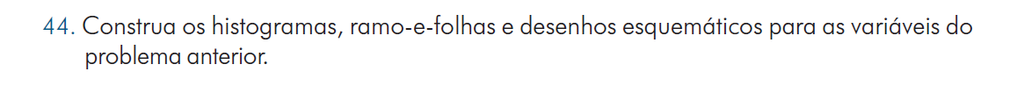

##### ºMonóxido de Carbono (CO)

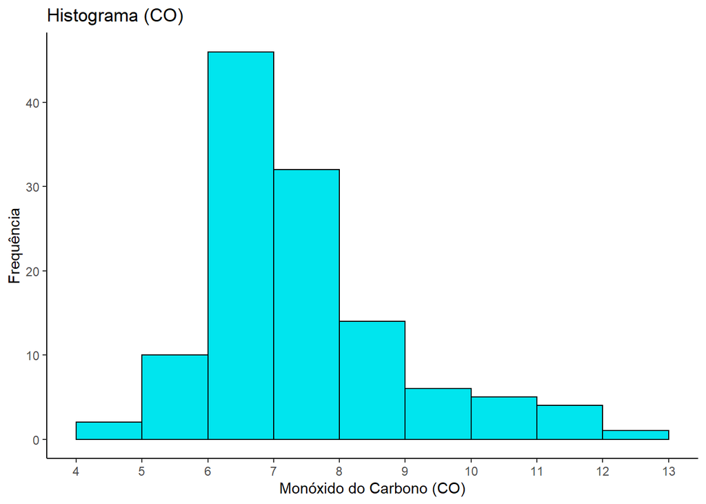

```r
ggplot(data = cd_poluicao, aes(x = co)) +
  geom_histogram(breaks = seq(4, 13),
                 col="gray1",
                 fill = "turquoise2") +
  labs(title = "Histograma (CO)",
       x = "Monóxido do Carbono (CO)",
       y = "Frequência") +
  scale_x_continuous(breaks=seq(4,13)) +
  theme_classic()
```

Ramo-e-folhas (CO)

```r
stem(cd_poluicao$co)
```

```
##
##   The decimal point is at the |
##
##    4 | 77
##    5 | 12
##    5 | 55677789
##    6 | 1111122222222233333444444
##    6 | 5666677777899999999
##    7 | 00122233444
##    7 | 5566777778888899999999
##    8 | 012334
##    8 | 55678999
##    9 | 0114
##    9 | 557
##   10 | 1333
##   10 | 8
##   11 | 4
##   11 | 69
##   12 | 0
##   12 | 5
```

Desenho esquemático

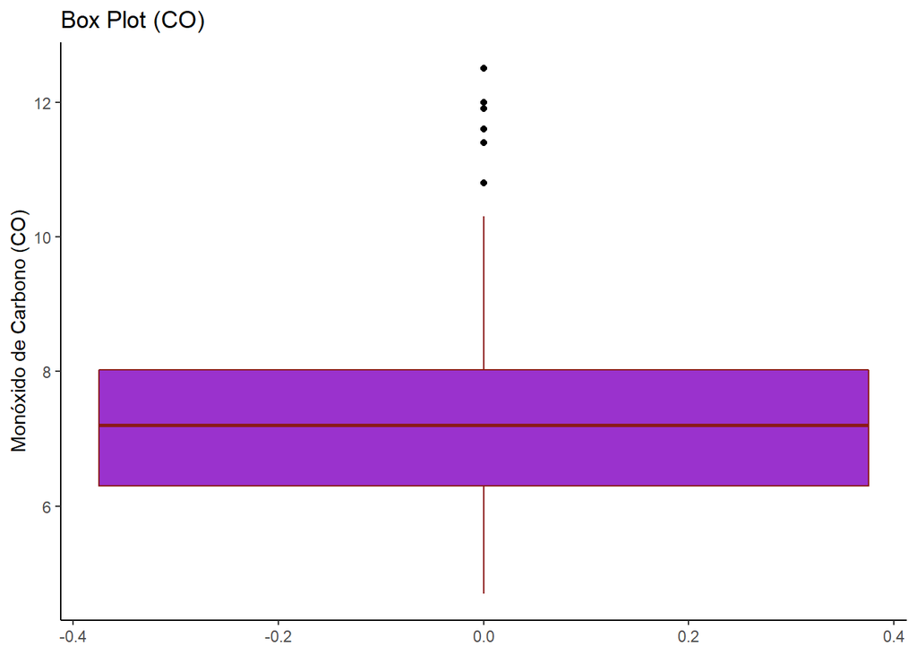

```r
ggplot(data = cd_poluicao, aes(y=co)) +
  geom_boxplot(outlier.colour = "black",
               col = "firebrick4",
               fill = "darkorchid3") +
  labs(title="Box Plot (CO)",
       y = "Monóxido de Carbono (CO)") +
  theme_classic()
```

##### ºSalário de Mecânicos

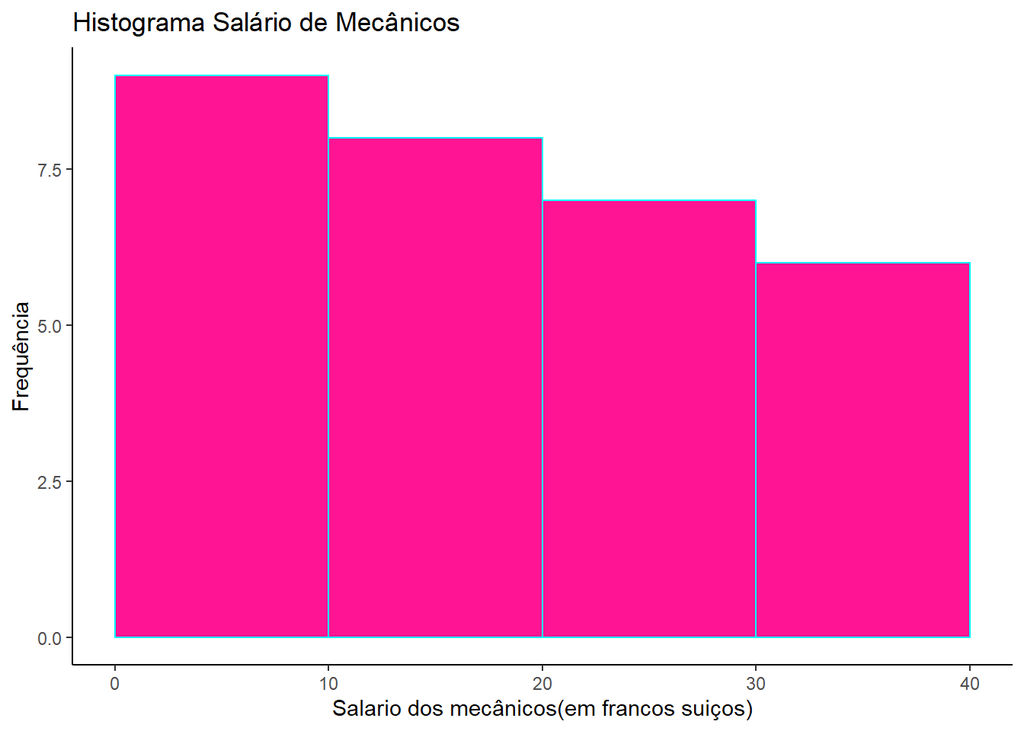

```r
ggplot(data = cd_salarios, aes(x = Mecânico)) +
  geom_histogram(fill = "deeppink",
                 col = "cyan1",
                 breaks = seq(0,40,10)) +
  labs(title = "Histograma Salário de Mecânicos",
       x = "Salario dos mecânicos(em francos suiços)",
       y = "Frequência") +
  theme_classic()
```

Ramo-e-folhas

```r
stem(cd_salarios$Mecânico, scale = 4)
```

```
##
##   The decimal point is at the |
##
##    1 | 7
##    2 |
##    3 | 8
##    4 |
##    5 | 28
##    6 | 26
##    7 |
##    8 | 37
##    9 | 7
##   10 |
##   11 | 1
##   12 | 15
```

[output cut: 27 more lines]

Desenho esquemático

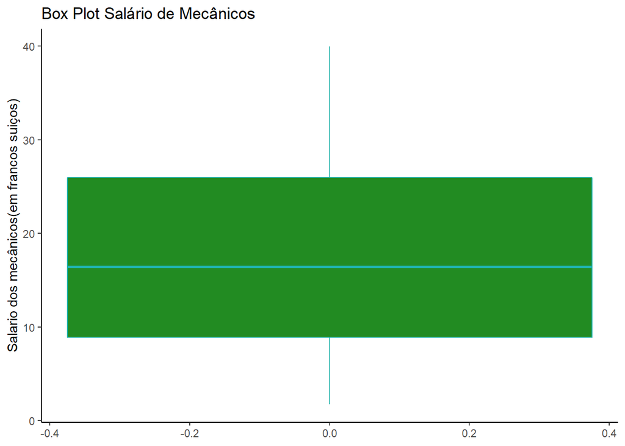

```r
ggplot(data = cd_salarios, aes(y = Mecânico)) +
  geom_boxplot(fill = "forestgreen",
               colour = "lightseagreen") +
  labs(title = "Box Plot Salário de Mecânicos",
       y = "Salario dos mecânicos(em francos suiços)") +
  theme_classic()
```

##### ºPreço dos Veículos

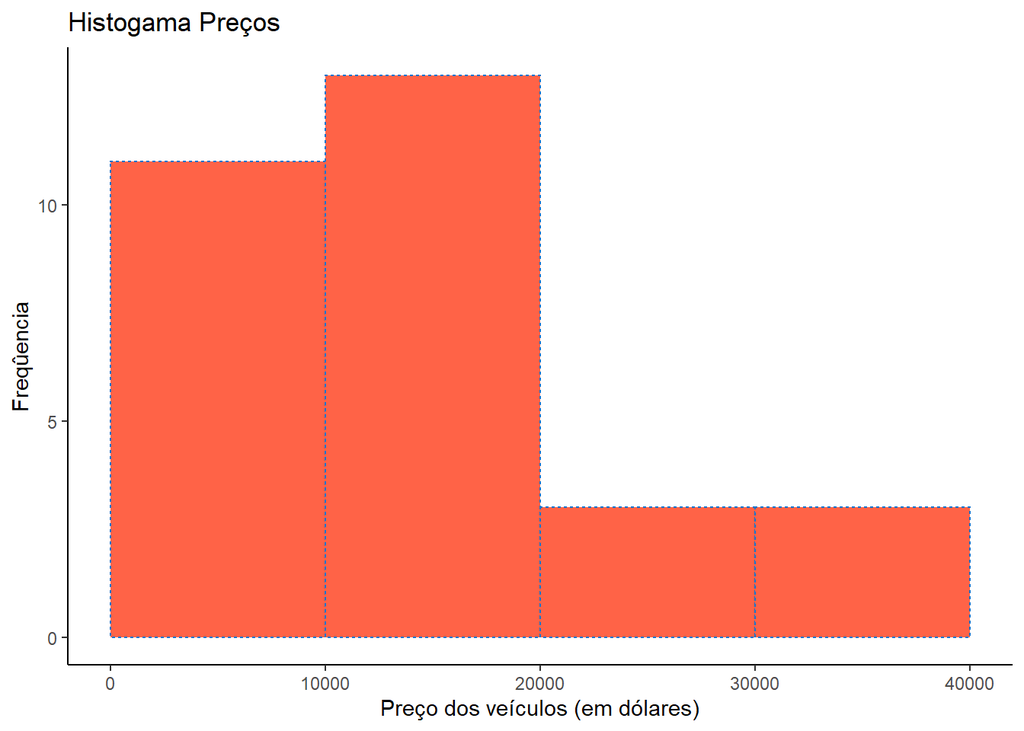

```r
ggplot(data = cd_veiculos, aes(x = preco)) +
  geom_histogram(linetype="dotted",
                 col = "dodgerblue3",
                 fill = "tomato",
                 breaks = seq(0,40000,10000)) +
  labs(title = "Histogama Preços",
       x = "Preço dos veículos (em dólares)",
       y = "Freqûencia") +
  theme_classic()
```

Ramo-e-folhas

```r
stem(cd_veiculos$preco, scale = 4)
```

```
##
##   The decimal point is 3 digit(s) to the right of the |
##
##    5 | 37
##    6 | 23337
##    7 | 78
##    8 |
##    9 | 34
##   10 | 58
##   11 | 46
##   12 | 099
##   13 | 178
##   14 | 5
##   15 | 5
##   16 | 3
```

[output cut: 22 more lines]

Desenho esquemático

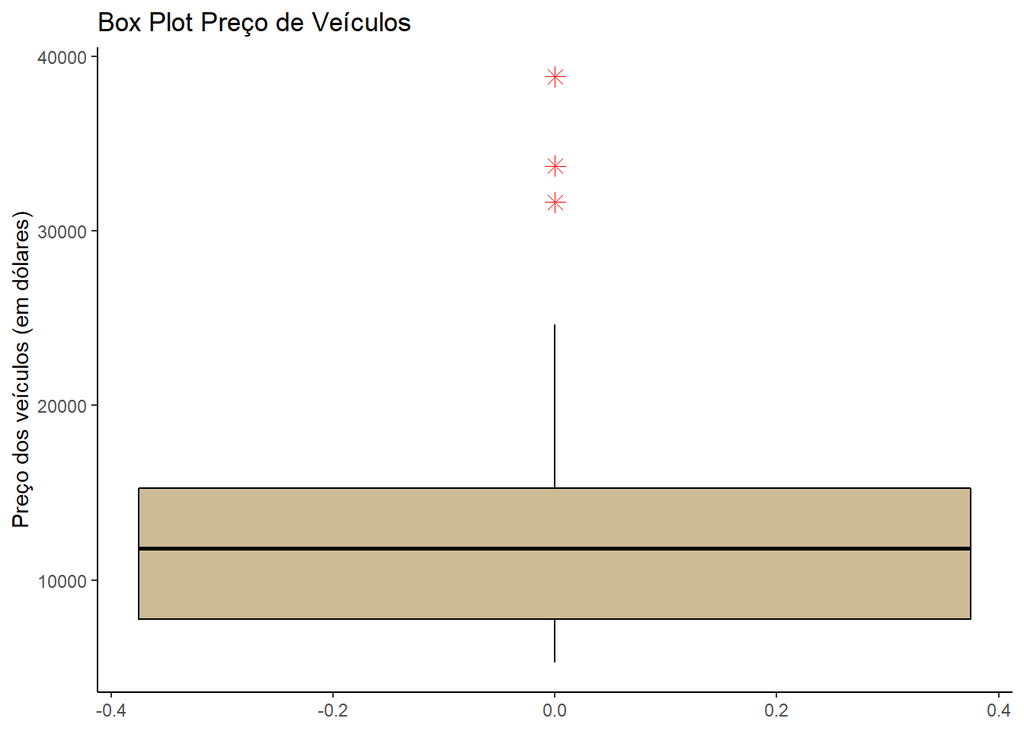

```r
ggplot(data = cd_veiculos, aes(y = preco)) +
  geom_boxplot(fill = "wheat3",
               col = "black",
               outlier.color = "red",
               outlier.shape = 8,
               outlier.size = 3) +
  labs(title = "Box Plot Preço de Veículos",
       y = "Preço dos veículos (em dólares)") +
  theme_classic()
```

### Questão 46

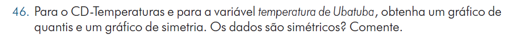

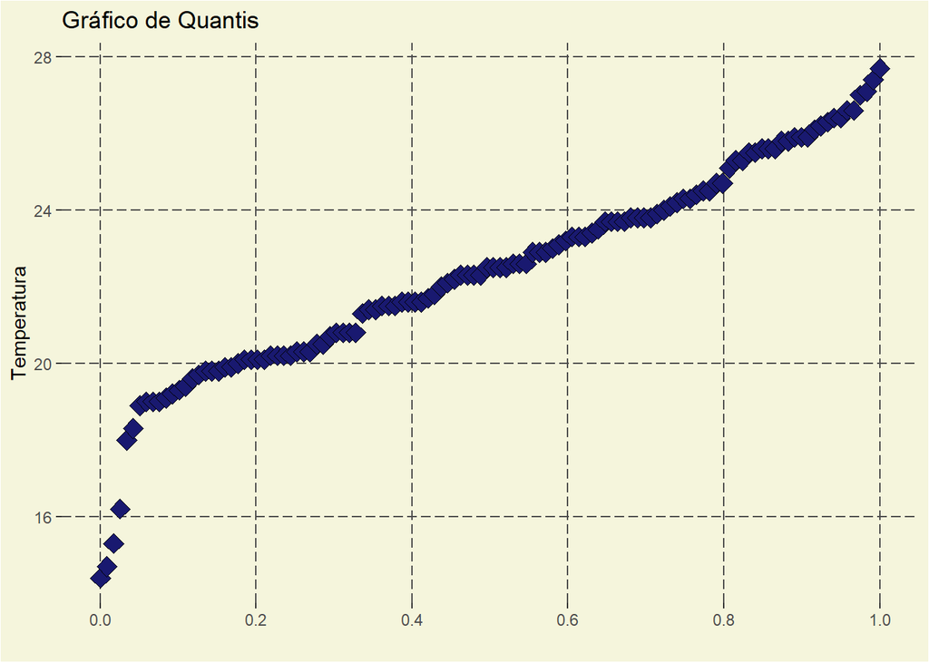

```r
Ubatuba <- cd_temperaturas$ubatuba
Ubatuba <- sort(Ubatuba)

ggplot(data = cd_temperaturas,
        aes(x = seq(0,1,length.out = 120), y = Ubatuba)) +
    geom_point(shape = 23,
               fill = "midnightblue",
               size = 3.8) +
    scale_x_continuous(breaks = seq(0,1,0.2)) +
    labs(title = "Gráfico de Quantis",
         x = " ",
         y = "Temperatura") +
    theme(plot.background = element_rect(fill = "beige"),
          panel.background = element_rect(fill = "beige"),
          panel.grid = element_line(linetype = "longdash",
                                    colour = "gray30"),
          panel.grid.minor = element_line(colour = "beige"))
```

```r
#Vamos usar que ui = q2(mediana) - xi e vi = x[n+1-i] - q2
#Então como i vai do primeiro elemento (x1) à mediana, vamos considerar i como de 1 até
#metade das observações (i = n/2)

i <- 1:(length(Ubatuba)/2)
#Temos que  1≤($\leq$)i≤($\geq$)60
i
```

```
##  [1]  1  2  3  4  5  6  7  8  9 10 11 12 13 14 15 16 17 18 19 20 21 22 23 24 25
## [26] 26 27 28 29 30 31 32 33 34 35 36 37 38 39 40 41 42 43 44 45 46 47 48 49 50
## [51] 51 52 53 54 55 56 57 58 59 60
```

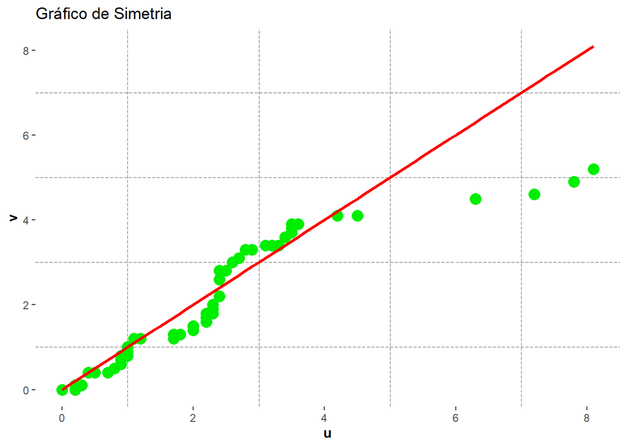

```r
#Agora, vamos calcular os ui
ui <- median(Ubatuba)-Ubatuba[i]
#Para calcular os vi, vamos apenas reordernar o vetor em ordem decrescente e #naturalmente obteremos o resultado que se quer.
Ubatuba_D <- sort(Ubatuba, decreasing = TRUE)
vi <- Ubatuba_D[i]-median(Ubatuba_D)

#Por fim, podemos fazer o gráfico de simetria em relação à reta u=v (em vermelho)
ggplot(data = NULL, aes(x = ui, y = vi)) +
  geom_point(shape = 19,
             colour = "green2",
             size = 4) +
  geom_line(data = NULL, aes(x = u, y = v),
            col = "red",
            size = 1.2) +
  theme(panel.grid = element_line(linetype = "dashed",
                                  colour = "white"),
        panel.grid.minor = element_line(linetype = "longdash",
                                        colour = "gray40"),
        panel.background = element_rect(fill = "white"),
        axis.title = element_text(face = "bold")) +
  labs(title = "Gráfico de Simetria",
       x = "u",
       y = "v")
```

# Capítulo 4

### Questão 37

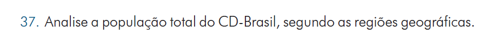

A partir da análise dos Box Plots das regiões geográficas brasileiras, notamos a região sudeste com uma distribuição anormal em relação às demais e isso se deve ao fato de conter o Estado de São Paulo, que possui uma população bastante acima da média da sua região e da média nacional. Também observamos que a região Norte é a que possui uma distribuição mais simétrica dentre as regiões, e que a região Sul, ao contrário da Nordeste e Centro-Oeste, tem uma distribuição assimétrica à esquerda.

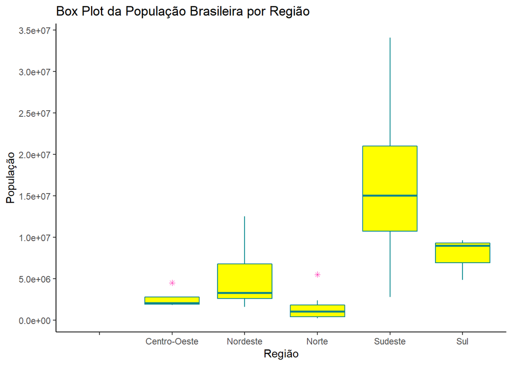

```r
ggplot(data = cd_brasil, aes(x = regiao, y = total)) +
  geom_boxplot(outlier.colour = "maroon1",
               outlier.shape = 8,
               fill = "yellow1",
               col = "turquoise4") +
  labs(title = "Box Plot da População Brasileira por Região",
       x = "Região",
       y = "População") +
  scale_y_continuous(breaks = seq(0,35000000,5000000)) +
  theme_classic()
```

### Questão 39

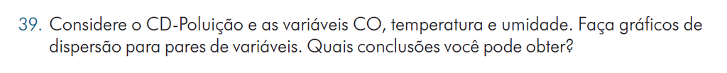

```r
CO <- sort(cd_poluicao$co)
Temperatura <- sort(cd_poluicao$temp)
Umidade <- sort(cd_poluicao$umid)

GDP1 <- ggplot(data = cd_poluicao, aes(x = CO, y = temp)) +
  geom_point(shape = 23,
             fill = "yellow1",
             size = 3) +
  scale_x_continuous(breaks = seq(0,14, 2),
                     limits = c(0,14)) +
  scale_y_continuous(limits = c(0,25)) +
  labs(title = "Gráfico de dispersão 1: Monóxido de Carbono (CO) X Temperatura",
       x = "Monóxido de Carbono (CO)",
       y = "Temperaura (°C)") +
  theme_classic() +
  theme(panel.grid = element_line(linetype = "dashed",
                                  colour = "white"),
        panel.grid.minor = element_line(linetype = "longdash",
                                        colour = "gray40"))


GDP2 <- ggplot(data = cd_poluicao, aes(x = Temperatura, y = umid)) +
  geom_point(shape = 24,
             fill = "magenta1",
             size = 3) +
  scale_x_continuous(breaks = seq(0,25,5),
                     limits = c(0,25)) +
  scale_y_continuous(breaks = seq(0,100,20),
                     limits = c(0,100)) +
  labs(title = "Gráfico de dispersão 2: Temperatura X Umidade",
       x = "Temperatura (°C)",
       y = "Umidade") +
  theme_classic() +
  theme(panel.grid = element_line(linetype = "dashed",
                                  colour = "white"),
        panel.grid.minor = element_line(linetype = "longdash",
                                        colour = "gray40"))

GDP3 <- ggplot(data = cd_poluicao, aes(x = Umidade, y = co)) +
  geom_point(shape = 25,
             fill = "mediumspringgreen",
             size = 3) +
  scale_x_continuous(breaks = seq(0,100,20),
                     limits = c(0,100)) +
  scale_y_continuous(breaks = seq(0,14, 2),
                     limits = c(0,14)) +
  labs(title = "Gráfico de disersão 3: Umidade X Monóxido de Carbono (CO)", x = "Umidade",
       y = "Monóxido de Carbono (CO)") +
  theme_classic() +
  theme(panel.grid = element_line(linetype = "dashed",
                                  colour = "white"),
        panel.grid.minor = element_line(linetype = "longdash",
                                        colour = "gray40"))
```

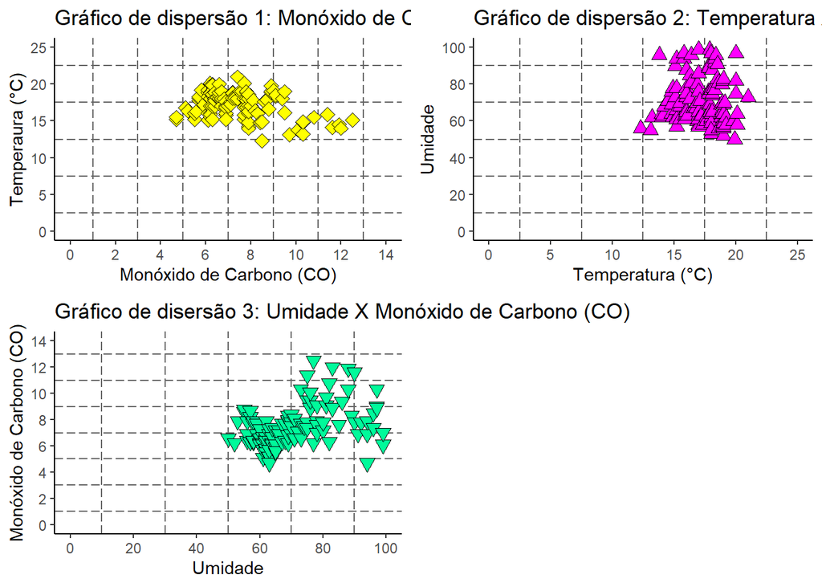

```r
ggarrange(GDP1, GDP2, GDP3, ncol = 2, nrow = 2,
          heights = 2, widths = 15, vjust = -5)
```